# 人脸识别调用测试

## FACE++人脸识别远程图片

```python
# -*- coding: utf-8 -*-
import urllib.request
import urllib.error
import time
import json
from pprint import pformat

def print_result(hit, result):
    print(hit)
    print('\n'.join("  " + i for i in pformat(result, width=75).split('\n')))

def printFuctionTitle(title):
    return "\n"+"-"*60+title+"-"*60;
# 美化打印


def detect_face1(path):

    http_url = 'https://api-cn.faceplusplus.com/facepp/v3/detect'
    key = "qiwSdNzkJOL2bxum7uPXpiVmracTBfT-"
    secret = "PYxQLmQCBaQH5AbCfx5V8zIkgMvdVsYW"
    image_url= path
    #     filepath = path
    boundary = '----------%s' % hex(int(time.time() * 1000))
    data = []
    data.append('--%s' % boundary)
    data.append('Content-Disposition: form-data; name="%s"\r\n' % 'api_key')
    data.append(key)
    data.append('--%s' % boundary)
    data.append('Content-Disposition: form-data; name="%s"\r\n' % 'api_secret')
    data.append(secret)
    data.append('--%s' % boundary)
    #     fr = open(filepath, 'rb')
    #     data.append('Content-Disposition: form-data; name="%s"; filename=" "' % 'image_file')
    #     data.append('Content-Type: %s\r\n' % 'application/octet-stream')
    #     data.append(fr.read())
    #     fr.close()
    data.append('Content-Disposition: form-data; name="%s"\r\n' % 'image_url')
    data.append(image_url)
    data.append('1')
    data.append('--%s' % boundary)
    data.append('Content-Disposition: form-data; name="%s"\r\n' % 'return_attributes')
    data.append(
        "gender,age,emotion")
    data.append('--%s--\r\n' % boundary)

    for i, d in enumerate(data):
        if isinstance(d, str):
            data[i] = d.encode('utf-8')

    http_body = b'\r\n'.join(data)

    # build http request
    req = urllib.request.Request(url=http_url, data=http_body)

    # header
    req.add_header('Content-Type', 'multipart/form-data; boundary=%s' % boundary)

    try:
        # post data to server
        resp = urllib.request.urlopen(req, timeout=5)
        # get response
        qrcont = resp.read()
        # if you want to load as json, you should decode first,
        # for example: json.loads(qrount.decode('utf-8'))
        JSON = json.loads(qrcont.decode('utf-8'))
        print_result(printFuctionTitle("面孔识别"), JSON)
    except urllib.error.HTTPError as e:
        print(e.read().decode('utf-8'))

# 人脸识别模块
# 训练集都为女性，图三为三人女性图片

A = ['https://cms.qn.img-space.com/product/159/889/cecVn4De8DeTo.jpg?imageView2/2/w/700/h/2000/q/100/ignore-error/1/',
     'https://cms.qn.img-space.com/product/159/885/ce3e6JSAK6poE.jpg?imageView2/2/w/700/h/2000/q/100/ignore-error/1/',
     'https://cms.qn.img-space.com/product/159/887/ceQdBAk4IjVlw.jpg?imageView2/2/w/700/h/2000/q/100/ignore-error/1/'
    ]
# 输入图片路径

for i in A:
    detect_face1(i)
# 输出结果
```

```
------------------------------------------------------------面孔识别------------------------------------------------------------
  {'face_num': 1,
   'faces': [{'attributes': {'age': {'value': 22},
                             'emotion': {'anger': 0.069,
                                         'disgust': 0.021,
                                         'fear': 0.23,
                                         'happiness': 1.964,
                                         'neutral': 97.674,
                                         'sadness': 0.021,
                                         'surprise': 0.021},
                             'gender': {'value': 'Female'}},
              'face_rectangle': {'height': 183,
                                 'left': 222,
                                 'top': 563,
                                 'width': 183},
              'face_token': 'f4d38f6c76794b1c2e17d78d5f365a71'}],
   'image_id': '1qBdhj23Bo3djrnL/eYKxQ==',
   'request_id': '1577193706,d7efe0e6-ba7c-4637-920f-a7ea231a6f52',
   'time_used': 2125}

------------------------------------------------------------面孔识别------------------------------------------------------------
  {'face_num': 1,
   'faces': [{'attributes': {'age': {'value': 19},
                             'emotion': {'anger': 0.053,
                                         'disgust': 0.053,
                                         'fear': 0.053,
                                         'happiness': 0.066,
                                         'neutral': 41.363,
                                         'sadness': 3.117,
                                         'surprise': 55.294},
                             'gender': {'value': 'Female'}},
              'face_rectangle': {'height': 130,
                                 'left': 157,
                                 'top': 112,
                                 'width': 130},
              'face_token': '3b21e05fde66fc7da32c1df9c0660e82'}],
   'image_id': 'X2PwfcyatO2DVXxWO/61ZA==',
   'request_id': '1577193709,1cd9fdef-e4ae-42f0-b005-01b405482c86',
   'time_used': 1065}

```

[output cut: 32 more lines]

```
                                         'disgust': 0.029,
                                         'fear': 0.029,
                                         'happiness': 0.029,
                                         'neutral': 56.952,
                                         'sadness': 42.418,
                                         'surprise': 0.029},
                             'gender': {'value': 'Male'}},
              'face_rectangle': {'height': 118,
                                 'left': 281,
                                 'top': 150,
                                 'width': 118},
              'face_token': 'e4232be0cc58cf10c84a4675f2bcf1ef'}],
   'image_id': 'V9KVti55++g9JcQPViRFhg==',
   'request_id': '1577193710,1a773631-d01d-4758-9026-ddfcfb050f43',
   'time_used': 918}
```

## AZURE人脸识别

```python
import requests
import json
from pprint import pformat

def print_result(hit, result):
    print(hit)
    print('\n'.join("  " + i for i in pformat(result, width=75).split('\n')))

def printFuctionTitle(title):
    return "\n"+"-"*60+title+"-"*60;
# 美化打印
def detect_face2(path):
    subscription_key = "8a9de7ccdb694b3c8332553e4536685b"
    assert subscription_key

    face_api_url = 'https://westcentralus.api.cognitive.microsoft.com/face/v1.0/detect'

    image_url = path
    headers = {'Ocp-Apim-Subscription-Key': subscription_key}

    params = {
        'returnFaceId': 'true',
        'returnFaceLandmarks': 'false',
        'returnFaceAttributes': 'age,gender,emotion',
    #     headPose,smile,facialHair,glasses,hair,makeup,occlusion,accessories,blur,exposure,noise',
    }

    response = requests.post(face_api_url, params=params,
                             headers=headers, json={"url": image_url})
    # res_azure = json.dumps(response.json())
    res_azure = response.json()
    print_result(printFuctionTitle("面孔识别"), res_azure)


# 输入图片路径

for i in A:
    detect_face2(i)
# 输出结果
```

[output not shown]

## 百度人脸识别

```python
# 首先pip install baidu-aip
# SDK文档链接http://ai.baidu.com/docs#/Face-Python-SDK/top
import base64
from aip import AipFace
def print_result(hit, result):
    print(hit)
    print('\n'.join("  " + i for i in pformat(result, width=75).split('\n')))

def printFuctionTitle(title):
    return "\n"+"-"*60+title+"-"*60;
# 美化打印

APP_ID = '17258712'
API_KEY = 'KCgWosGOE2BmvGsaHcR0A7vy'
SECRET_KEY = 'GVyatD054rM6emTKXF99GrIIM5g9wGqx'

client = AipFace(APP_ID, API_KEY, SECRET_KEY)

def face_check(img_data):

    image = img_data
    imageType = "URL"

    """ 调用人脸检测 """
    client.detect(image, imageType)

    """ 如果有可选参数 """
    options = {}
    options["face_field"] = "age,emotion,gender"
    options["max_face_num"] = 10

    """ 带参数调用人脸检测 """
    res = client.detect(image, imageType, options)
#     print(res)
    try:
        res_list = res['result']
    except Exception as e:
        res_list = None
    print_result(printFuctionTitle("面孔识别"), res_list)


B= [
    'https://imgsa.baidu.com/forum/w%3D580/sign=a86e1e729beef01f4d1418cdd0ff99e0/7a4a78b5c9ea15ce2a32471fb9003af33b87b2bd.jpg',
    'https://imgsa.baidu.com/forum/w%3D580/sign=83ecc7ddbdfb43161a1f7a7210a54642/8e478cc379310a550d9879e2b84543a9832610dd.jpg',
    'https://imgsa.baidu.com/forum/w%3D580/sign=204b362944fbfbeddc59367748f1f78e/846e6234970a304e5ffb07ecdec8a786c8175cb8.jpg'
   ]

for i in B:
    face_check(i)
```

[output not shown]

### 结论

#### 1. 兼容性

- 百度人脸识别测试图片URL许多都不能读取，最后必须把图片上传到百度产品的网站上才能获取图片
- 百度上传本地图片时需要转化为BASE64编码才能上传

年龄识别

性别识别

情绪识别

多人识别

### 图片集

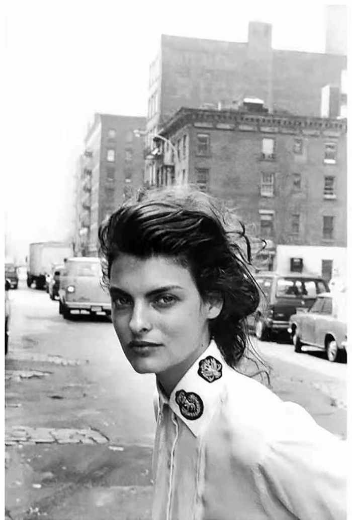

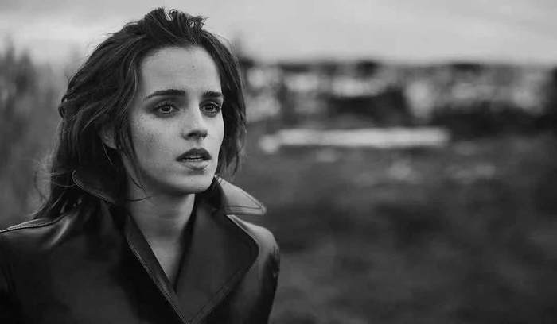

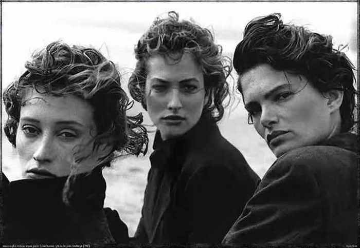